# Taller individual 2

##### Deserta vs Perfil

La gran mayoria de los estudiantes que desertan estan en perfil de normal, se deberia reajustar el metodo con el cual se elijen a los perfiles de los estudiantes que desertan y no desertan y tambien se puede ver que hay un 7.5% de estudiantes que no desertan y de colocan en perfil de riesgo.

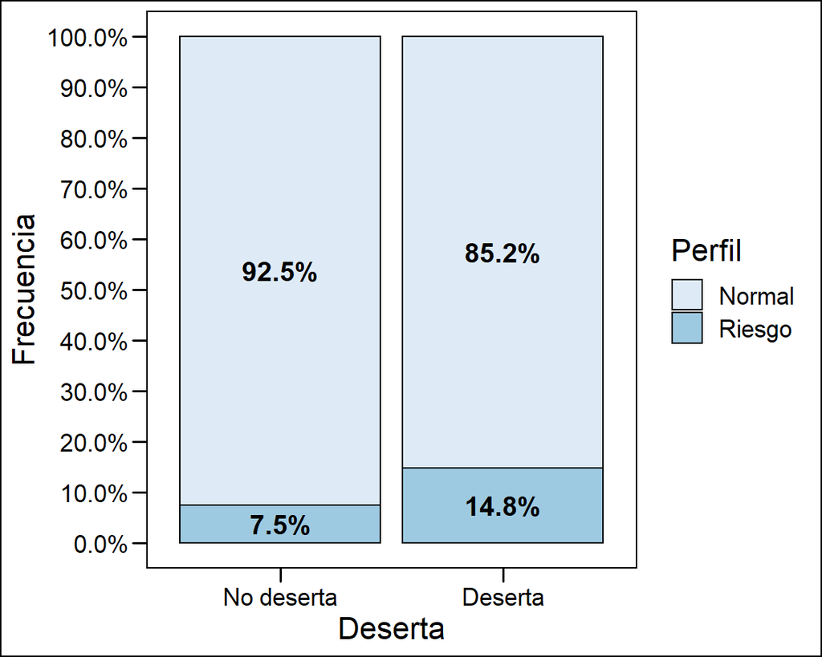

##### Deserta vs Procedencia

El porcentaje de estudiantes que no deserta es menor en los estudiantes que provienen de afuera de Cali que de los estudiantes que provienen de Cali, teniendo una diferencia de aproximadamente el 10% de estudiantes. El porcentaje de estudiantes que deserta es mayor de los estudiantes que provienen fuera de Cali que los que proceden de Cali, pero es un diferencia muy pequeña.  
De esto se puede obtener que hay relacion entre los estudiantes que desertan y los estudiantes que provienen de fuera de Cali, aumentando el porcentaje de estudiantes que deserta si vienen de fuera de Cali.

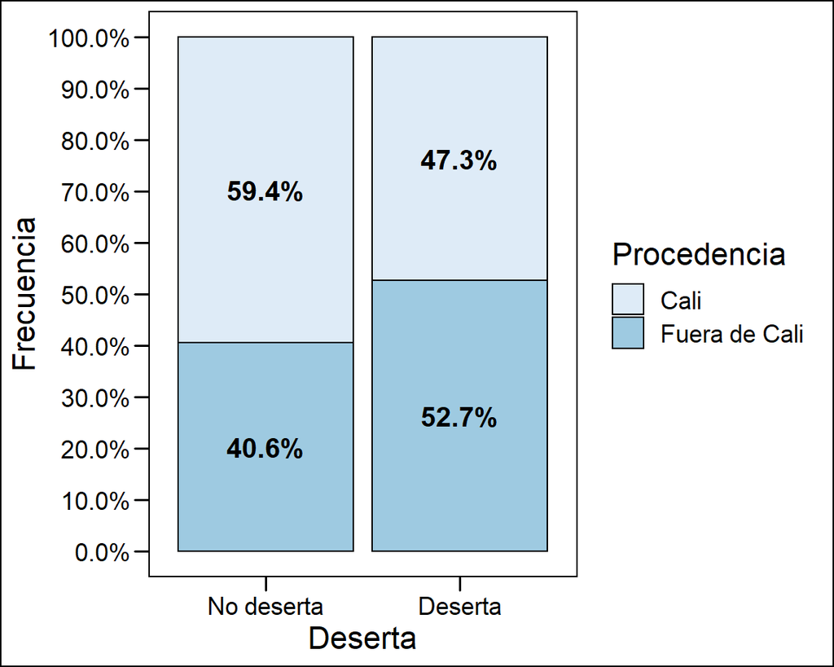